# ggplot 101 practice solutions

Daniel Quiroz and you

9/13/2022

# 1 Introduction

We are going to practice using ggplot today, focusing on the data, aesthetic, and geom layers. We are going to use data from the [TidyTuesday](https://www.tidytuesday.com/) project. For this recitation, we are going to use the [Giant Pumpkins](https://github.com/rfordatascience/tidytuesday/tree/master/data/2021/2021-10-19) data which is collected from the [Great Pumpkin Commonwealth](https://gpc1.org/).

At the end of of this module you will create of of this descriptive plots

## 1.1 Libraries

```r
library(tidyverse)
library(lubridate)
```

## 1.2 Read in data

```r
pumpkins_raw <- readr::read_csv('https://raw.githubusercontent.com/rfordatascience/tidytuesday/master/data/2021/2021-10-19/pumpkins.csv')
```

# 2 Full pipe and plot

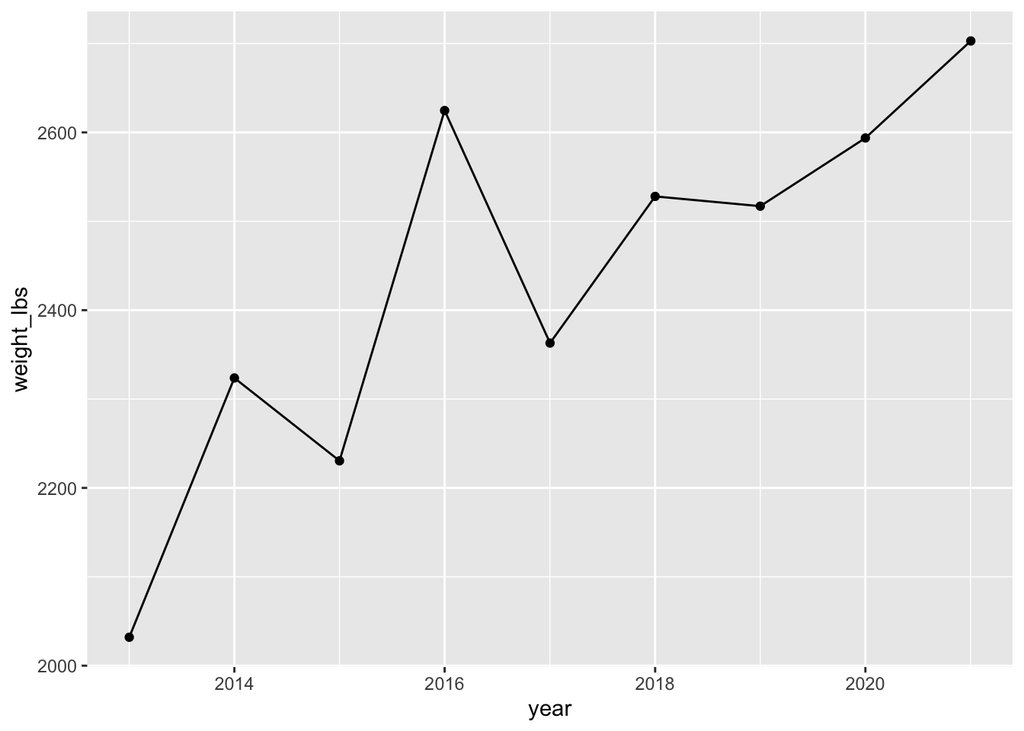

```r
pumpkins_raw %>%
  separate(col = "id", into = c("year", "type")) %>%
  filter(type == "P" & place == "1") %>%
  mutate(weight_lbs = str_remove(weight_lbs, ",") ) %>%
  mutate(weight_lbs = as.numeric(weight_lbs)) %>%
  mutate(year = ymd(year, truncated = 2)) %>%
    ggplot(aes(year, weight_lbs)) +
    geom_point() +
    geom_line()
```

# 3 Playing around

### 3.0.1 Try using different geoms besides `geom_point()` and `geom_line()`. Which might make sense in this situation?

Showing wrangling first then will plot after.

```r
pumpkins_raw %>%
  separate(col = "id", into = c("year", "type")) %>%
  filter(type == "P" & place == "1") %>%
  mutate(weight_lbs = str_remove(weight_lbs, ",") ) %>%
  mutate(weight_lbs = as.numeric(weight_lbs)) %>%
  mutate(year = ymd(year, truncated = 2L))
```

```
## # A tibble: 9 × 15
##   year       type  place weight_…¹ growe…² city  state…³ country gpc_s…⁴ seed_…⁵
##   <date>     <chr> <chr>     <dbl> <chr>   <chr> <chr>   <chr>   <chr>   <chr>
## 1 2013-01-01 P     1         2032  Mathis… Napa  Califo… United… Uesugi… "2009 …
## 2 2014-01-01 P     1         2324. Meier,… Pfun… Other   Switze… Europa… "2009 …
## 3 2015-01-01 P     1         2230. Wallac… Gree… Rhode … United… SNGPG … "2009 …
## 4 2016-01-01 P     1         2625. Willem… Deur… East F… Belgium Europa… "2145 …
## 5 2017-01-01 P     1         2363  Hollan… Sumn… Washin… United… Safewa… "2145.…
## 6 2018-01-01 P     1         2528  Geddes… Bosc… New Ha… United… Deerfi… "1911 …
## 7 2019-01-01 P     1         2517  Haist,… Clar… New Yo… United… Ohio V… "2005 …
## 8 2020-01-01 P     1         2594. Paton,… Ever… England United… Royal … "1875 …
## 9 2021-01-01 P     1         2703. Cutrup… Radd… Tuscany Italy   Campio… "1885.…
## # … with 5 more variables: pollinator_father <chr>, ott <chr>,
## #   est_weight <chr>, pct_chart <chr>, variety <chr>, and abbreviated variable
## #   names ¹weight_lbs, ²grower_name, ³state_prov, ⁴gpc_site, ⁵seed_mother
## # ℹ Use `colnames()` to see all variable names
```

Can also parse the date in a slightly different way.

```r
(pumpkins_to_plot <- pumpkins_raw %>%
  separate(col = "id", into = c("year", "type")) %>%
  filter(type == "P" & place == "1") %>%
  mutate(weight_lbs = str_remove(weight_lbs, ",") ) %>%
  mutate(weight_lbs = as.numeric(weight_lbs)) %>%
  mutate(year = as.POSIXct(year, format = "%Y")) %>%
  mutate(year = as.Date(year, format = "%Y")))
```

```
## # A tibble: 9 × 15
##   year       type  place weight_…¹ growe…² city  state…³ country gpc_s…⁴ seed_…⁵
##   <date>     <chr> <chr>     <dbl> <chr>   <chr> <chr>   <chr>   <chr>   <chr>
## 1 2013-09-20 P     1         2032  Mathis… Napa  Califo… United… Uesugi… "2009 …
## 2 2014-09-20 P     1         2324. Meier,… Pfun… Other   Switze… Europa… "2009 …
## 3 2015-09-20 P     1         2230. Wallac… Gree… Rhode … United… SNGPG … "2009 …
## 4 2016-09-20 P     1         2625. Willem… Deur… East F… Belgium Europa… "2145 …
## 5 2017-09-20 P     1         2363  Hollan… Sumn… Washin… United… Safewa… "2145.…
## 6 2018-09-20 P     1         2528  Geddes… Bosc… New Ha… United… Deerfi… "1911 …
## 7 2019-09-20 P     1         2517  Haist,… Clar… New Yo… United… Ohio V… "2005 …
## 8 2020-09-20 P     1         2594. Paton,… Ever… England United… Royal … "1875 …
## 9 2021-09-20 P     1         2703. Cutrup… Radd… Tuscany Italy   Campio… "1885.…
## # … with 5 more variables: pollinator_father <chr>, ott <chr>,
## #   est_weight <chr>, pct_chart <chr>, variety <chr>, and abbreviated variable
## #   names ¹weight_lbs, ²grower_name, ³state_prov, ⁴gpc_site, ⁵seed_mother
## # ℹ Use `colnames()` to see all variable names
```

### 3.0.2 Can you color all the lines blue?

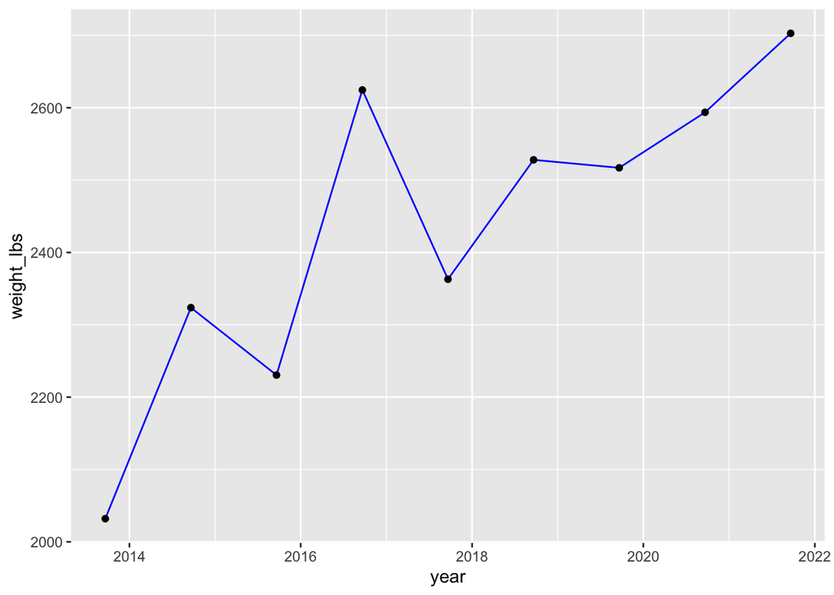

```r
pumpkins_to_plot %>%
  ggplot(aes(x = year, y = weight_lbs)) +
  geom_line(color = "blue") +
  geom_point()
```

### 3.0.3 Can you color the data based on year?

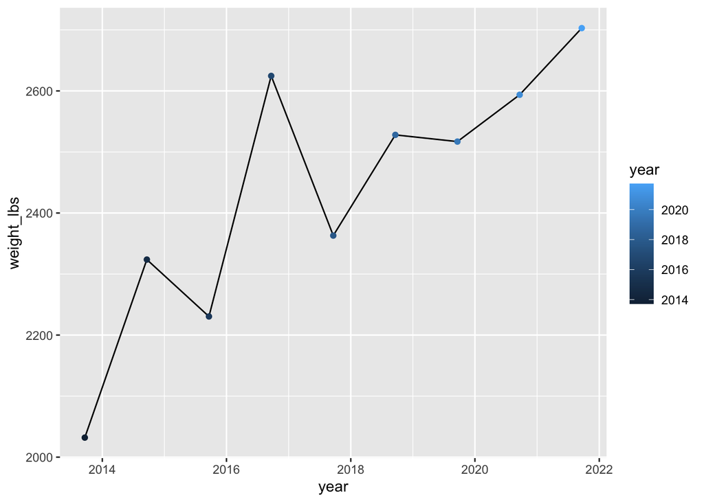

```r
pumpkins_to_plot %>%
  ggplot(aes(x = year, y = weight_lbs)) +
  geom_line() +
  geom_point(aes(color = year))
```

Because date is a continuous variable, we are getting a continuous color scale, which might not be what we want. We can get around it by setting date as a factor.

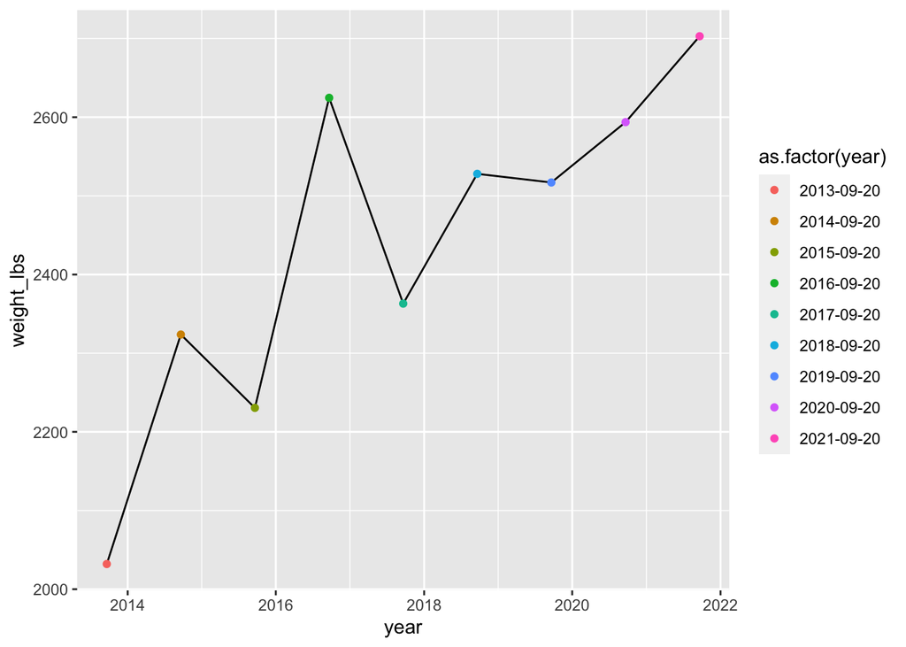

```r
pumpkins_to_plot %>%
  ggplot(aes(x = year, y = weight_lbs)) +
  geom_line() +
  geom_point(aes(color = as.factor(year)))
```

### 3.0.4 Can you color and change shape based on country?

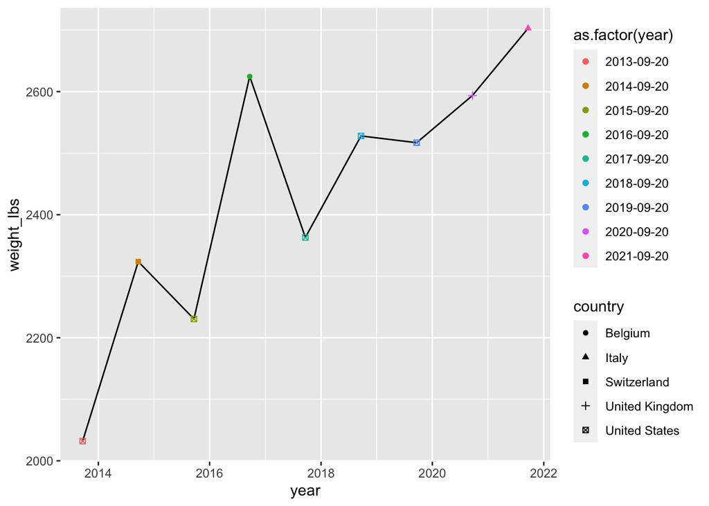

```r
pumpkins_to_plot %>%
  ggplot(aes(x = year, y = weight_lbs)) +
  geom_line() +
  geom_point(aes(color = as.factor(year), shape = country))
```

### 3.0.5 Can you make a plot showing the distribution of weights of all giant pumpkins entered in 2021?

```r
pumpkins_2021 <- pumpkins_raw %>%
  separate(col = "id", into = c("year", "type")) %>%
  filter(type == "P" & year == 2021) %>%
  mutate(weight_lbs = str_remove(weight_lbs, ",") ) %>%
  mutate(weight_lbs = as.numeric(weight_lbs)) %>%
  mutate(year = ymd(year, truncated = 2L))
```

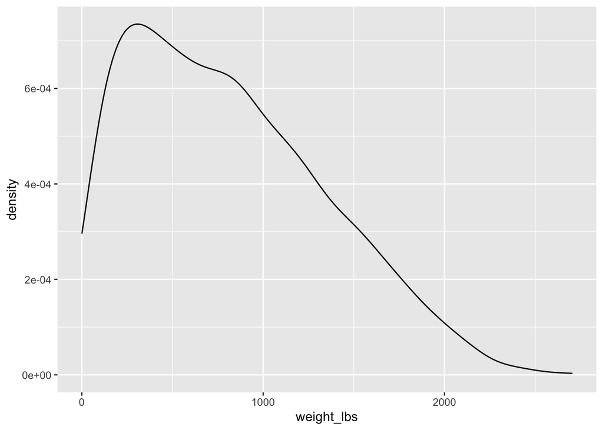

```r
pumpkins_2021 %>%
  ggplot(aes(x = weight_lbs)) +
  geom_density()
```

### 3.0.6 Can you make a boxplot showing the distribution of weights of all giant pumpkins across all years?

Also can you add all the datapoints on top of the boxplot? Is this a good idea? Might there be a better geom to use than a boxplot?

```r
pumpkins_all <- pumpkins_raw %>%
  separate(col = "id", into = c("year", "type")) %>%
  filter(type == "P") %>%
  mutate(weight_lbs = str_remove(weight_lbs, ",") ) %>%
  mutate(weight_lbs = as.numeric(weight_lbs)) %>%
  mutate(year = ymd(year, truncated = 2L))
```

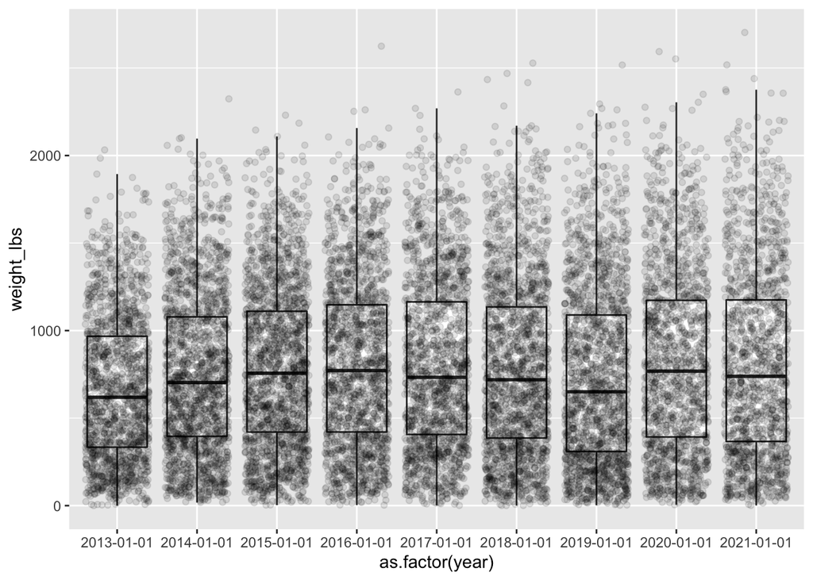

```r
pumpkins_all %>%
  ggplot(aes(x = as.factor(year), y = weight_lbs)) +
  geom_boxplot(outlier.shape = NA) +
  geom_jitter(alpha = 0.1)
```

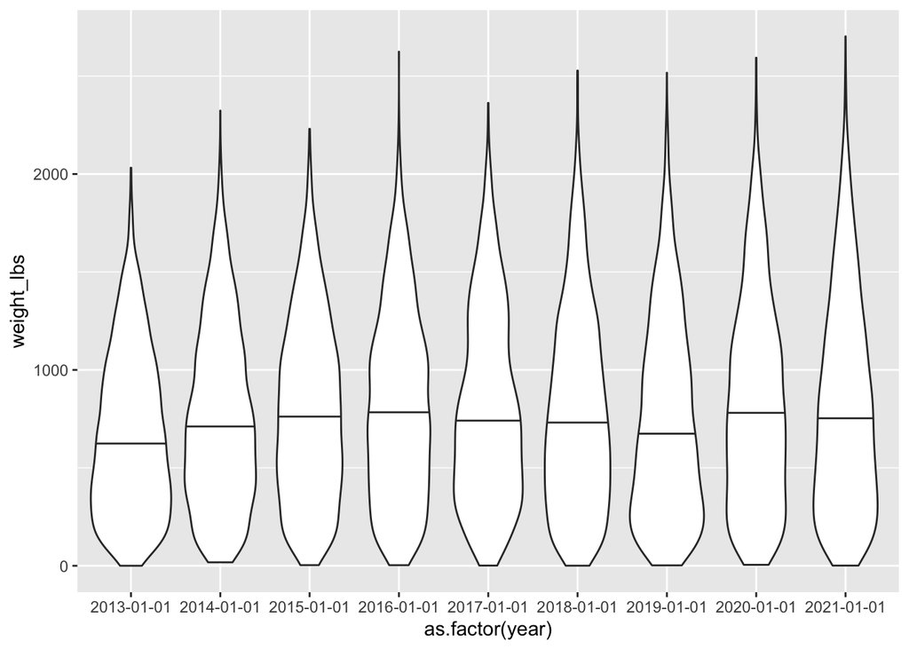

```r
pumpkins_all %>%
  ggplot(aes(x = as.factor(year), y = weight_lbs)) +
  geom_violin(draw_quantiles = 0.5)
```